# Teoria das Probabilidades

Gustavo Jun Yakushiji

Outubro de 2022

A **teoria das probabilidades** é um ramo da matemática que desenvolve e avalia modelos para descrever **fenômenos aleatórios**, servindo como base teórica para o desenvolvimento de técnicas estatísticas que visam descrever fenômenos aleatórios.

# 1 Conceitos básicos

## 1.1 Tipos de fenômenos

### a) Determinísticos

Fenômenos que, repetidos **inúmeras vezes**, em **condições semelhantes**, geram resultados essencialmente **idênticos**.

*Exemplos*: Leis da física (gravidade); Leis da química (a uma certa temperatura, um determinado sólido passará para o estado líquido).

### b) Aleatórios

Fenômenos (ou experimentos) que, repetidos **inúmeras vezes** sob as **mesmas condições**, geram **resultados diferentes**. Nesse caso, sabemos todos os possíveis resultados, porém, não sabemos qual será o resultado **antes** de sua realização (**a priori**).

*Exemplos*: Lançamento de moeda e dado; resultado de eventos esportivos e jogos de azar; condições climáticas.

Os fenômenos aleatórios serão os objetos de estudo para os demais tópicos descritos a seguir.

## 1.2 Fenômenos aleatórios

### a) Espaço amostral ($\Omega$)

Conjunto de todos os possíveis resultados de um experimento aleatório.

*Exemplos*:

- Lançamento de dados: $\Omega$ = {1,2,3,4,5,6};
- Lançamento de moeda: $\Omega$ = {cara, coroa};
- Resultado de uma partida de futebol: $\Omega$ = {vitória, derrota, empate};
- Peso de frutos: $\Omega$ = (0,$\infty$) = $\mathbb{R}^+$.

### b) Pontos amostrais ($\omega$)

Elementos que compõem o espaço amostral ($\Omega$).

*Exemplo*: Lançamento de moeda: $\omega_1$ = cara; $\omega_2$ = coroa.

No R, para criarmos um espaço amostral, utilizamos a função `c()`, tendo como argumentos os pontos amostrais (elementos) que o compõem.

```r
# Exemplo: espaço amostral de um dado
(dado <- c(1,2,3,4,5,6))
```

```
[1] 1 2 3 4 5 6
```

```r
# Exemplo: espaço amostral de uma moeda
(moeda <- c("cara", "coroa"))
```

```
[1] "cara"  "coroa"
```

Também podemos utilizar a função `seq()` para determinar uma sequência numérica, tendo como argumentos o primeiro número (`from =`), o último número (`to =`) e a sequência numérica (*de quanto em quanto* - `by =`).

```r
# Utilizando a função seq()
(dado_seq <- seq(from = 1, to = 6, by = 1))
```

```
[1] 1 2 3 4 5 6
```

### c) Eventos (A, B, C …)

Subconjunto do espaço amostral ($\Omega$). Podemos ter diferentes classificações de eventos. A seguir, exemplificaremos com o lançamento de dado, tendo como espaço amostral $\Omega$ = {1,2,3,4,5,6}.

- **Evento simples**: A = {3};
- **Evento composto**: B = *números ímpares* = {1,3,5}
- **Evento impossível**: C = {31} = $\phi$ (não se pode obter tal valor em um dado);
- **Evento certo**: $1 \leq D \leq 6$; D = $\Omega$.

# 2 Teoria dos conjuntos

Utilizada para definir operações com eventos.

## 2.1 Conjunto vazio ($Ø$)

Conjunto sem elementos, denotado por $Ø$.

## 2.2 União ($A \cup B$)

Evento que consiste na união de **todos** os pontos amostrais (elementos) de ambos os eventos envolvidos. A união é denotada por $A \cup B$.

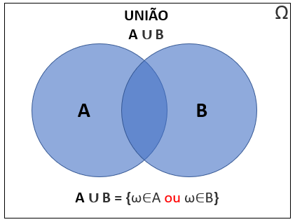

## 2.3 Intersecção ($A \cap B$)

Evento composto pelos pontos amostrais (elementos) em **comum** entre os eventos. A intersecção é denotada por $A \cap B$.

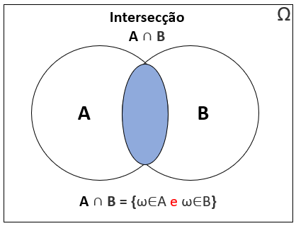

## 2.4 Evento disjunto (ou mutuamente exclusivo)

Evento que não podem ocorrer simultaneamente, ou seja, possuem intersecção vazia ($A \cap B =$ {Ø}).

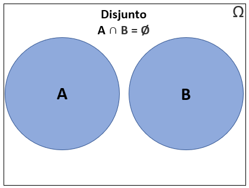

## 2.5 Evento complementar ($A^c$ ou $\bar A$)

Complemento ($A^c$ ou $\bar A$) do evento proposto ($A$) ou eventos que a união é o espaço amostral ($\Omega$).

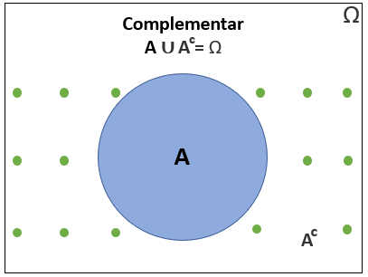

# 3 Conceitos de Probabilidade

## 3.1 Definição Clássica de Probabilidade (a priori)

A probabilidade da ocorrência de uma evento $A$ é denotada por $P(A)$, sendo definida como a razão entre $m$ elementos do evento e $n$ resultados igualmente prováveis do espaço amostral $\Omega$.

$$P(A) = \frac{m}n$$

*Exemplo*: considere o lançamento de um dado “honesto” - todos os valores possuem mesma probabilidade de ocorrência - cujo espaço amostral é dados por $\Omega$ = {1,2,3,4,5,6}, logo $n = 6$:

- Qual a probabilidade de ocorrer o número 3? $m=1$, logo $P(3) = 1/6$;
- Qual a probabilidade de ocorrer número par? $m=3$, logo $P(par) = 3/6=1/2$.

## 3.2 Definição Frequentista de Probabilidade (a posteriori)

Considere que um experimento aleatório $\epsilon$ seja repetido $n$ vezes e o evento $A$ tenha ocorrido $m$ vezes. Então, a frequência relativa $f_r$ do evento $A$ é dado por:

$$f_r=\frac{m}n$$

*Exemplo*: Considere o lançamento de uma moeda:

- Caso seja lançada 500 vezes ($n=500$), com 240 resultados sendo cara ($m=240$), temos: $f_r(cara)=240/500 = 0.48$.

No R, utilizamos a função `sample()` para simular frequências de probabilidade, tendo como argumentos: `x =` para definir o espaço amostral; `size =` para número de repetições; e `replace = TRUE` para assumir a reposição dos elementos a cada nova repetição realizada.

```r
# Exemplo: lançamento de moeda 10 vezes
(moeda <- c("cara", "coroa"))
```

```
[1] "cara"  "coroa"
```

```r
(resultado_moedas <- sample(x = moeda, size = 10, replace = TRUE))
```

```
 [1] "coroa" "coroa" "cara"  "cara"  "coroa" "cara"  "cara"  "coroa" "cara"
[10] "cara"
```

Podemos criar tanto uma tabela de frequências absolutas, como de probabilidades (ou frequências relativas) para quantificarmos as ocorrências dos eventos aleatórios. Para isso, utilizamos as funções `table()` e `prop.table()`, respectivamente.

```r
# Frequência absoluta do lançamento das moedas
(Freq.Abs = table(resultado_moedas))
```

```
resultado_moedas
 cara coroa
    6     4
```

```r
# Frequência relativa do lançamento das moedas
(Probabilidade = prop.table(table(resultado_moedas)))
```

```
resultado_moedas
 cara coroa
  0.6   0.4
```

```r
# Tabela com ambas as frequências
cbind(Freq.Abs, Probabilidade)
```

```
      Freq.Abs Probabilidade
cara         6           0.6
coroa        4           0.4
```

Outra definição: caso o número de repetições tender ao infinito ($n\to \infty$), a frequência relativa de um evento $A$ tenderá para uma constante $P(A)$. Em outras palavras, quanto mais repetições de um experimento aleatório são realizadas, maior a tendência de que a probabilidade de ocorrência dos eventos sejam iguais entre si.

$$\lim_{n\to\infty}f_r(A) =
P(A)$$

Para verificarmos tal definição, faremos dois experimentos aleatórios, com o auxílio das seguintes funções criadas:

```r
# Função de simulação
prob.frequentista <- function(esp.amostral, repeticoes){

  library(tidyverse)

  exp <- sample(x = esp.amostral,
                size = repeticoes,
                replace = TRUE)

  Freq.abs <- table(exp)

  Probabilidade <- prop.table(table(exp)) %>% round(3)

  resultado <- cbind(Freq.abs, Probabilidade) %>%
    data.frame() %>% rownames_to_column("Elementos")

  return(resultado)
}
```

```r
# Função que retorna gráficos de frequências e probabilidades das simulações
grafico <- function(simulacao){
  library(ggplot2)
  library(patchwork)

  repet <- sum(simulacao$Freq.abs)

  p1 <- ggplot(data = simulacao,
               aes(x = Elementos, y = Freq.abs, fill = Elementos))+
    geom_col(show.legend = F)+
    geom_text(aes(label = Freq.abs),
              color = "white",
              vjust = 2.5)+
    labs(title = paste0(repet, " repetições"),
         x = "",
         y = "Freq. absoluta")+
    theme_bw()

  p2 <- ggplot(data = simulacao,
               aes(x = Elementos, y = Probabilidade, fill = Elementos))+
    geom_col(show.legend = F)+
    geom_text(aes(label = Probabilidade),
              color = "white",
              vjust = 2.5)+
    labs(title = paste0(repet, " repetições"),
         x = "",
         y = "Probabilidade")+
    theme_bw()

  p1+p2
}
```

### a) Lançamento de moeda

```r
# Espaço amostral da moeda
(moeda <- c("cara", "coroa"))
```

```
[1] "cara"  "coroa"
```

- Simulando 100 lançamentos (n = 100):

```r
# Simulando 100 lançamentos de moeda
(moeda_n100 <- prob.frequentista(esp.amostral = moeda,
                                 repeticoes = 100))
```

```
  Elementos Freq.abs Probabilidade
1      cara       57          0.57
2     coroa       43          0.43
```

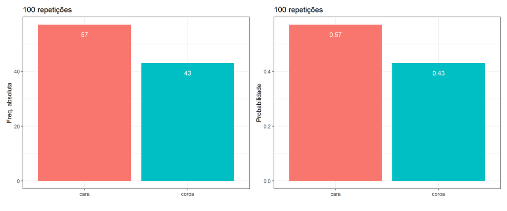

```r
# Gráficos
grafico(simulacao = moeda_n100)
```

- Simulando 1000 lançamentos (n = 1000):

```r
# Simulando 1000 lançamentos de moeda
(moeda_n1000 <- prob.frequentista(esp.amostral = moeda,
                                  repeticoes = 1000))
```

```
  Elementos Freq.abs Probabilidade
1      cara      516         0.516
2     coroa      484         0.484
```

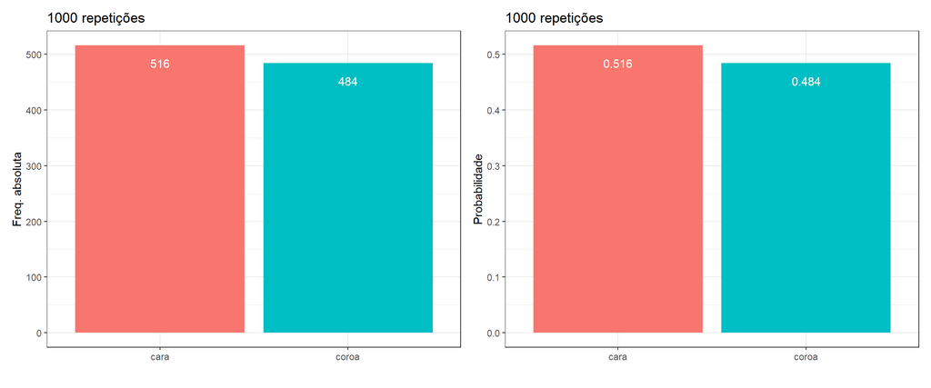

```r
# Gráficos
grafico(simulacao = moeda_n1000)
```

- Simulando 1.000.000 de lançamentos (n = 1000000):

```r
# Simulando 1.000.000 de lançamentos de moeda
(moeda_n.milhao <- prob.frequentista(esp.amostral = moeda,
                                     repeticoes = 1000000))
```

```
  Elementos Freq.abs Probabilidade
1      cara   500119           0.5
2     coroa   499881           0.5
```

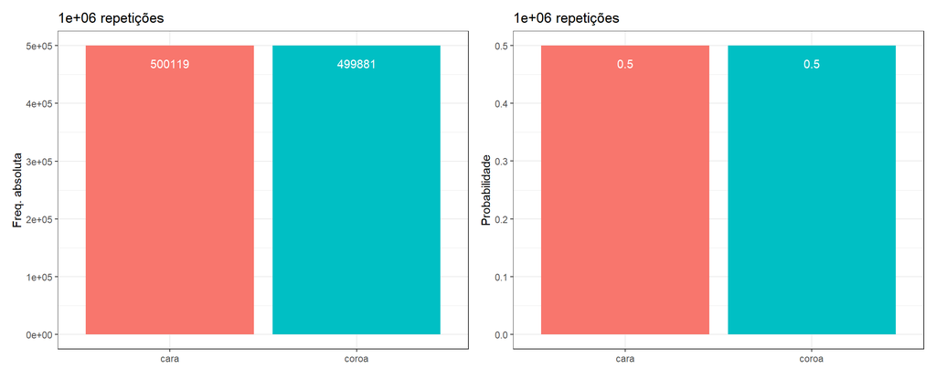

```r
# Gráficos
grafico(simulacao = moeda_n.milhao)
```

Perceba que, conforme aumentamos o número de repetições, as probabilidades de ambos eventos se aproximam da igualdade entre si (tendem à constante $P(A) = P(B) = 1/2$).

### b) Lançamento de dado

Da mesma maneira, podemos simular o lançamento de dado, cujo espaço amostral é dado por:

```r
# Espaço amostral do dado
(dado <- c(1,2,3,4,5,6))
```

```
[1] 1 2 3 4 5 6
```

- Simulando 100 lançamentos (n = 100):

```r
# Simulando 100 lançamentos de dado
(dado_n100 <- prob.frequentista(esp.amostral = dado,
                                 repeticoes = 100))
```

```
  Elementos Freq.abs Probabilidade
1         1       16          0.16
2         2       19          0.19
3         3       11          0.11
4         4       14          0.14
5         5       18          0.18
6         6       22          0.22
```

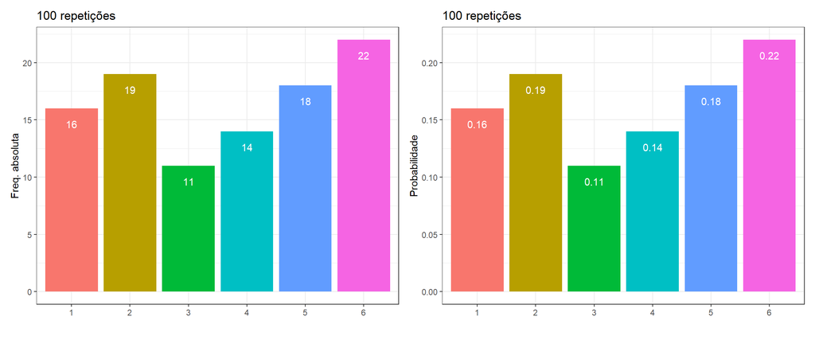

```r
# Gráficos
grafico(simulacao = dado_n100)
```

- Simulando 1000 lançamentos (n = 1000):

```r
# Simulando 1000 lançamentos de dado
(dado_n1000 <- prob.frequentista(esp.amostral = dado,
                                  repeticoes = 1000))
```

```
  Elementos Freq.abs Probabilidade
1         1      174         0.174
2         2      159         0.159
3         3      171         0.171
4         4      170         0.170
5         5      155         0.155
6         6      171         0.171
```

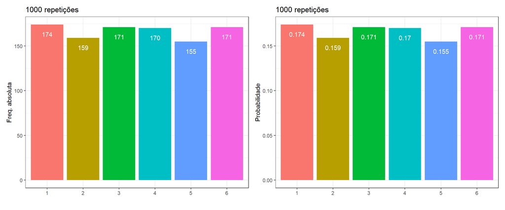

```r
# Gráficos
grafico(simulacao = dado_n1000)
```

- Simulando 1.000.000 de lançamentos (n = 1000000):

```r
# Simulando 1.000.000 de lançamentos de dado
(dado_n.milhao <- prob.frequentista(esp.amostral = dado,
                                     repeticoes = 1000000))
```

```
  Elementos Freq.abs Probabilidade
1         1   166322         0.166
2         2   166470         0.166
3         3   166788         0.167
4         4   167124         0.167
5         5   166829         0.167
6         6   166467         0.166
```

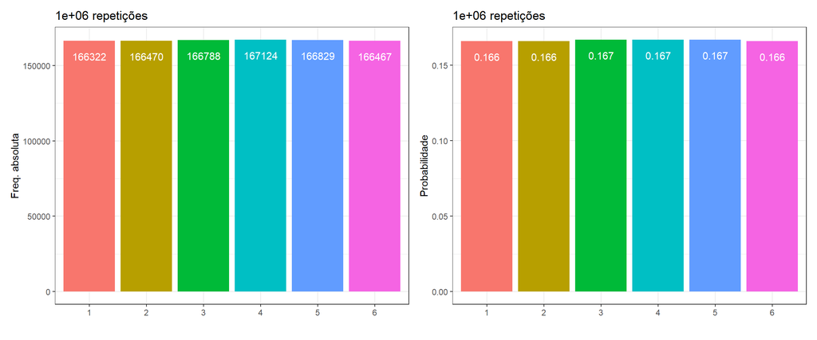

```r
# Gráficos
grafico(simulacao = dado_n.milhao)
```

Novamente, conforme aumentamos o número de repetições, as probabilidades de ambos eventos se aproximam da igualdade entre si (tendem à constante $P(1) = P(2) = ... = P(6) = 1/6$)

## 3.3 Definição Axiomática de Probabilidade

Considere os seguintes axiomas (propriedades) para um evento $A$, pertencente a um espaço amostral $\Omega$, cuja probabilidade é representada por $P(A)$:

1. $0 \leq P(A) \leq 1$: *o resultado da probabilidade de qualquer evento será um valor entre 0 e 1*;
2. $P(\Omega) = 1$: *a probabilidade do espaço amostral é igual a 1*;
3. Se $A_1$, $A_2$, …, $A_n$ forem, dois a dois, eventos disjuntos, então $P(\cup^n_{i=1}A_i) = \sum^n_{i=1}P(A_i)$: *a probabilidade da união de todos os eventos pertencentes a um espaço amostral é a somatória da probabilidade de todos os eventos pertencentes ao mesmo espaço amostral*.

Com isso, verificamos que:

1. $P(\phi)=0$: *a probabilidade de um evento vazio é 0*;
2. $P(A)=1-P(A^c)$: *A probabilidade de um evento é a subtração de 1 com a probabilidade do seu evento complementar*;
3. $P(A\cup B)=P(A)+P(B)-P(A\cap B)$, sendo $A$ e $B$ eventos quaisquer;
4. $P(A\cup B)=P(A)+P(B)$, caso $A$ e $B$ seja eventos disjuntos.

*Exemplo*: Supondo uma turma de alunos (M) e alunas (F) da ESALQ dos cursos de ciências biológicas (Bio) e engenharia agronômica (Agro), considere a seguinte tabela de frequências:

```
# A tibble: 3 × 4
  ` `       F     M Total
  <chr> <dbl> <dbl> <dbl>
1 Bio      16     8    24
2 Agro     21     5    26
3 Total    37    13    50
```

Podemos calcular algumas das seguintes probabilidades:

- Ser do sexo feminino: $P(F) = 37/50 = 0,74$;
- Ser do sexo masculino: $P(M) = 13/50 = 0,26$;
- Ser do curso de ciências biológicas: $P(Bio) = 24/50 = 0,48$;
- Ser do curso de eng. agronômica: $P(Agro) = 26/50 = 0,52$.
- Ser do sexo feminino **E** do curso de ciências biológicas:

$$P(F \cap Bio) = 16/50 =
0,32$$

- Ser do sexo feminino **OU** do curso de ciências biológicas:

$$P(F \cup Bio) = P(F) + P(Bio) - P(F \cap
Bio) \\ P(F \cup Bio)= 0,74 + 0,48 - 0,32\\P(F \cup
Bio)=0,90$$

- **Não** ser do sexo feminino, nem do curso de ciências biológicas:

$$P((F \cup Bio)^c) = 1 - P(F \cup Bio) \\
P((F \cup Bio)^c) = 1 - (P(F) + P(Bio) - P(F \cap Bio)) \\ P((F \cup
Bio)^c) = 1 - 0,90 \\ P((F \cup Bio)^c) = 0,10$$

Sugestão: *Como prática, calcule as demais probabilidades possíveis.*

## 3.4 Probabilidade Condicional e Independência

Seja $A$ e $B$ eventos do espaço amostral $\Omega$ e $P(B)>0$, sendo que a ocorrência do evento $B$ é condicionada pela ocorrência do evento $A$ ($P(B|A)$ - *probabilidade de A dado B*):

$$P(B|A) = \frac{P(A\cap
B)}{P(A)}$$

No caso inverso:

$$P(A|B) = \frac{P(A\cap
B)}{P(B)}$$

*Exemplo*: Em uma urna com 8 bolas vermelhas e 2 bolas brancas, retira-se 2 bolas, sem reposição. Defina $P(B|A)$, sendo:

- A = {primeira bola branca} **E** B = {segunda bola branca};

$$P(B|A) = \frac{P(A\cap B)}{P(A)} \\
P(B|A) = \frac{2/10*1/9}{2/10}=1/9 = 0,11$$

- C = {primeira bola branca} **E** D = {segunda bola vermelha};

$$P(D|C) = \frac{P(C\cap D)}{P(C)} \\
P(D|C) = \frac{2/10*8/9}{2/10}=8/9 = 0,89$$

## 3.5 Teorema da multiplicação (Regra do Produto)

Dado que:

$$P(A|B) = \frac{P(A\cap
B)}{P(B)}$$

Temos como **regra do produto** a seguinte equação:

$$P(A\cap B) = P(A|B)*P(B)$$

*Exemplo:* Qual a probabilidade de se obter dois ases seguidos em cartas de baralho com 52 cartas…

- Com reposição de carta?

$$P(A_1 \cap A_2) = P(A_2|A_1)*P(A_1) =
P(A_2)*P(A_1)=4/52*4/52=0.006$$

- Sem reposição de cartas?

$$P(A_1 \cap A_2) = P(A_2|A_1)*P(A_1) =
3/51*4/52=0.004$$

## 3.6 Eventos Independentes

Caso os eventos $A$ e $B$ sejam independentes (a ocorrência de um não interfira no outro):

$$P(B|A) = P(B)\\ou\\P(A|B) =
P(A)$$

Na regra do produto temos:

$$P(A\cap B)=P(B)*P(A|B) =
P(B)*P(A)\\ou\\P(A\cap B)=P(A)*P(B|A) = P(A)*P(B)$$

*Exemplo:* Considere lançamento de dados e os seguintes eventos. Posteriormente, responda: Os eventos são independentes?

- Evento A = *resultado é um número par* ($A = {2,4,6}$);
- Evento B = *resultado é um número menor ou igual a 4* ($B = {1,2,3,4}$).

Temos que:

- $P (A\cap B) = 2/6$;
- $P(A) = 3/6$;
- $P(B) = 4/6$.

$P(A\cap B)=P(A)*P(B) = 3/6*4/6 = 1/3$, e $P (A\cap B) = 2/6 = 1/3$; assim, pela definição, confirmamos que $P(A\cap B)=P(A)*P(B)$, logo são eventos independentes.